[figure not shown]

# Aula 25

## Processamento de Linguagem Natural & Análise de Sentimento

Este é um tutorial introdutório ao Processamento de Língua Natural *(Natural Language Processing, NLP)* e Análise de Sentimentos *(Sentiment Analysis)* visando apresentar os principais conceitos e métodos.

#### O que é?

NLP é um dos grandes campos de pesquisa de Inteligência Artificial, focado no tratamento, entendimento e interpretação de língua natural. Ao invés de termos dados estruturados em tabelas, colunas e linhas, *e.g.,* e preenchidos de acordo com algum padrão pré-definido ou até mesmo preenchido de mandeira pragmática, temos **dados desestruturados e textos livres**.

#### Casos de NLP

- Reconhecimento de fala *(Automatic Speech Recognition - ASR, )*
- Agentes conversacionais *(chatbots)*
- Tradução de textos *(Machine Translation)*
- Transcrição de textos
- Mineração de textos *(Text Mining)*
- Mineração de redes sociais
- Categorização, simplificação ou sumarização de textos
- Reconhecimento de Entidades *(Named Entity Recognition)*
- Análise de Sentimento *(Sentiment Analysis)*
- Etc.

#### Como funciona?

Claro que nada disso é mágica e tudo é realizado através de técnicas e análises léxicas, sintáticas e semânticas, além da compreensão de questões cognitivas, psicolinguísticas e estatísticas. **Jurafsky e Martin** descrevem NLP da seguinte forma em seu livro$^{1}$:

> *"No mínimo, um agente deve ser capaz de interagir com humanos por uma língua natural, o que inclui o entendimento de humanos através de uma do recohecimento de fala e língua natural (e, claro, leitura labial), e a comunicação com seres humanos por geração de língua natural e sintetização de fala. Também deveria ser capaz de recuperar informações (descobrir quais recursos textuais são necessários), extrair informações (fatos pertinentes a partir destes recursos) e inferir (desenhar conclusões baseadas em fatos conhecidos.*

Claramente estamos muito longe disso, muito longe de passar pelo teste de *Turing*$^{2}$. Ainda temos bastante dificuldade em compreender características comportamentais, sentimentais e filosóficas. Uma máquina ainda não é capaz de simular sentimentos **reais** (não apenas "positivo" e "negativo") ou compreender contextos. A falta de recursos (*córpus*, textos rotulados, etc) é gritante, especialmente para idiomas não tão populares (sim, nosso Português se enquadra aqui!).

Existe muita divergência no mercado sobre a realidade e o que **de fato** foi construído no estado-da-arte, mas uma frase de **Chomsky**$^{3}$ relata muito bem a realidade:

> *"Pouco pode ser dito com qualquer confiança a respeito da "arquitetura" da mente humana, e por esta razão eu propositalmente permaneço confuso em todo este tópico."*

Também gosto da visão de um grande pesquisador brasileiro chamado **Miguel Nicolelis** explanada em seu livro$^{4}$. sobre como ser capazes de simular *completamente* o cérebro humano, justamente pela forma como nosso sistema nervoso funciona.

#### Cursos

- [Natural Language Processing](https://www.youtube.com/watch?v=CXpZnZM63Gg&list=PL8FFE3F391203C98C), Stanford (by Jurafsky)
- [Sequence Models](https://www.coursera.org/learn/nlp-sequence-models), Coursera (by Andrew Ng @deeplearning.ai)
- [CS224n: Natural Language Processing with Deep Learning](http://web.stanford.edu/class/cs224n/), Stanford
- [Miracles of Human Language: An Introduction to Linguistics](https://www.coursera.org/learn/human-language), Coursera (by Universiteit Leiden, Meertens instituut, KNAW)

$^{1}$ [Speech and Language Processing, 2nd Edition](https://www.amazon.com/Speech-Language-Processing-Daniel-Jurafsky/dp/0131873210), Dan Jurafsky and James H. Martin  
$^{2}$ [Turing Test](http://www.psych.utoronto.ca/users/reingold/courses/ai/turing.html), University of Toronto $^{3}$ [An On-Line Interview with Noam Chomsky: On the nature of pragmatics and related issues](http://www.cogprints.org/126/1/chomsweb_399.html), Brain and Language, Volume 68, # 3, July 1999, pp. 393-401 $^{4}$ [O Cerebro Relativistico: Como Ele Funciona E Por Que Ele Não Pode Ser Simulado Por Uma Máquina de Turing](https://www.amazon.com.br/Cerebro-Relativistico-Funciona-Simulado-Maquina/dp/151463810X?tag=goog0ef-20&smid=A1ZZFT5FULY4LN&ascsubtag=46cb126c-655c-4a38-a18e-3f2f5089ce45), Miguel Nicolelis

[figure not shown]

### Caso de Uso

Vamos utilizar dados coletados no Twitter através da [API de Streaming](https://developer.twitter.com/en/docs/tutorials/consuming-streaming-data.html) durante um **debate dos presidenciáveis de 2018** na TV Gazeta em 09/09/2018.

A ideia é brincar bastante com língua natural e nada melhor do que publicações do Twitter.

Você pode pensar *"poxa, mas de novo Twitter"* ou *"isso não tem nada a ver com a realidade e não é um case que vou aplicar no mercado de trabalho"*, mas acreditem: **todas as empresas** querem ou já mineram dados de redes sociais.

Até gostaria de explorar o Facebook ou o LinkedIn, porém estas plataformas são fechadas e não disponibilizam nenhuma biblioteca ou API para a coleta de dados públicos.

### Dataset

Foram coletados *tweets* em **Português** das **17:10** até **18:48**, apenas uma pequena amostra com toda a zueira do *hue hue* brasileiro que deve ser apreciada.

[figure not shown]

### Atributos

O arquivo **debate_tweets-processed.csv** (~1.6MB) já está tratado e possui as seguintes [características](https://developer.twitter.com/en/docs/tweets/data-dictionary/overview/tweet-object):

- **text**: texto do *tweet*;
- **username**: nome do usuário;
- **date**: data da postagem;
- **year**: ano da postagem;
- **month**: mês da postagem;
- **day**: dia da postagem;
- **hour**: hora da postagem;
- **minute**: minuto da postagem;
- **second**: segundo da postagem.

**Existem outros atributos no JSON fornecido pela API, porém, não são relevantes para o conteúdo desta aula.*

## Configuração inicial

**Pandas**: biblioteca para manipulação de dados

```python
import pandas as pd
```

```python
pd.set_option('display.max_rows', 500)
pd.set_option('display.max_columns', 500)
pd.set_option('display.max_colwidth', 2500)
```

**Numpy**: biblioteca científica para manipulação de valores numéricos.

```python
import numpy as np
```

**gc**: limpeza de dados em memória.

```python
import gc
```

**Matplotlib, seaborn:** bibliotecas para visualização de dados.

```python
import matplotlib.pyplot as plt
import seaborn as sns
color = sns.color_palette()
sns.set(style="white")

%matplotlib inline
```

**spaCy:** biblioteca para processamento de língua natural:

```
!conda install -c conda-forge spacy -y
```

```python
import spacy
```

## Leitura de Dados

```python
tweets = pd.read_csv('data/debate_tweets-processed.csv', encoding='utf-8')
```

```python
tweets.iloc[:5]
```

|  | text | username | date | year | month | day | hour | minute | second |
| --- | --- | --- | --- | --- | --- | --- | --- | --- | --- |
| 0 | RT @MomentsBrasil: #Eleições2018 \n\nTudo sobre o debate entre os presidenciáveis de hoje 🗳️ \n\n📺Transmissão em vídeo ao vivo no Twitter\n⚡️Twe… | ByelCitando | 2018-09-09 17:11:34-07:00 | 2018 | 9 | 9 | 17 | 11 | 34 |
| 1 | RT @anyel: @pdevechi sem daciolo, sem debate. | ViniciusNikolod | 2018-09-09 17:11:35-07:00 | 2018 | 9 | 9 | 17 | 11 | 35 |
| 2 | RT @dntav_ian: @pdevechi Arrisca ser o debate mais produtivo do primeiro turno | ViniciusNikolod | 2018-09-09 17:11:37-07:00 | 2018 | 9 | 9 | 17 | 11 | 37 |
| 3 | @bchartsnet Querem ver ele em #1 ? divulgação é essencial pocs. Ciro 12 presidente. Hoje tem debate na TV gazeta as… https://t.co/7KdgLYcykI | vermelho05 | 2018-09-09 17:11:40-07:00 | 2018 | 9 | 9 | 17 | 11 | 40 |
| 4 | RT @Ricamconsult: Hoje à noite, teremos o debate presidencial mais esvaziado da História. Lula na prisão, Bolsonaro no hospital, Daciolo de… | varelaandre | 2018-09-09 17:11:43-07:00 | 2018 | 9 | 9 | 17 | 11 | 43 |

## Exploração de Dados

Temos uma base com um total de **8.822** *tweets*.

```python
len(tweets)
```

```
8822
```

Vamos plotar a frequencia dos *tweets* durante a **véspera** do debate.

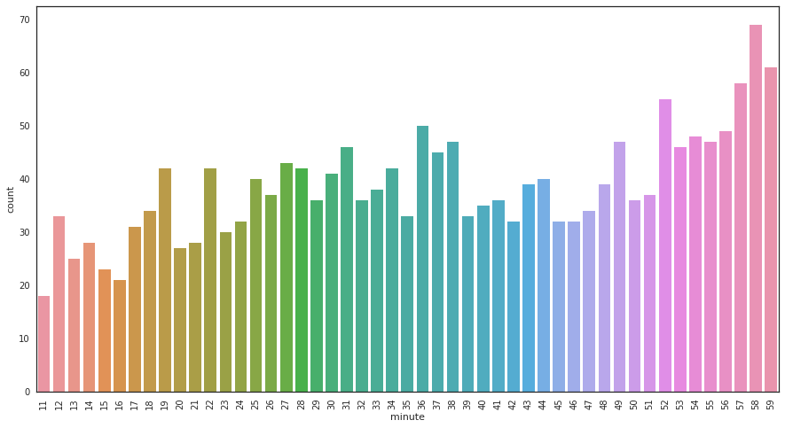

```python
fig, ax = plt.subplots(figsize=(15,8))
sns.countplot(x='minute', data=tweets.loc[tweets['hour']==17])
plt.xticks(rotation=90)
plt.show()
```

Vamos ver a **primeira hora** do debate.

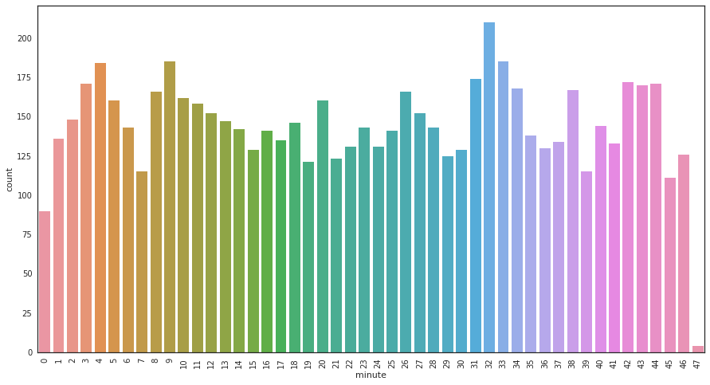

```python
fig, ax = plt.subplots(figsize=(15,8))
sns.countplot(x='minute', data=tweets.loc[tweets['hour']==18])
plt.xticks(rotation=90)
plt.show()
```

Em uma única imagem, vamos compará-las:

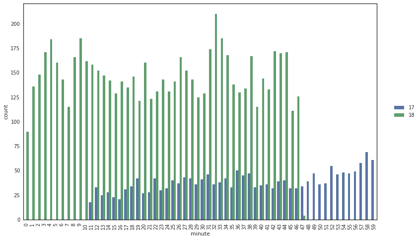

```python
fig, ax = plt.subplots(figsize=(15,8))
gplot = sns.countplot(x='minute', hue='hour', data=tweets)
plt.xticks(rotation=90)
box = gplot.axes.get_position()
gplot.axes.set_position([box.x0, box.y0, box.width * 0.85, box.height])
gplot.axes.legend(loc='center right', bbox_to_anchor=(1.12, 0.5), ncol=1)
plt.show()
```